# Graphics

DJM

11 April 2017

> “The simple graph has brought more information to the data analyst’s mind than any other device.” — John Tukey
- This week we’re going to learn how to use `ggplot2`, Hadley Wickham’s package for making graphics.
- This material is based on Chapter 3 of his book “`R` for data science”.
- That is your reading for this week (link on syllabus page).

## Why ggplot?

- `ggplot2` is a bit hard to get used to.
- But it’s figures are much better looking than `R`’s `plot` functions.
- Compare:

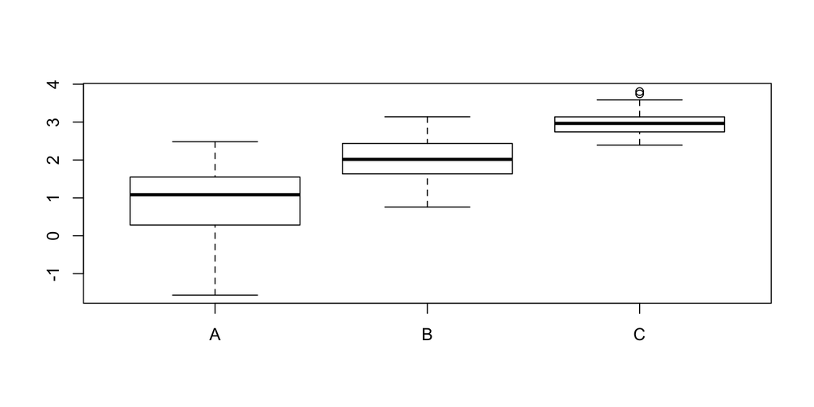

```r
boxplot(vals~classes, data=df)
```

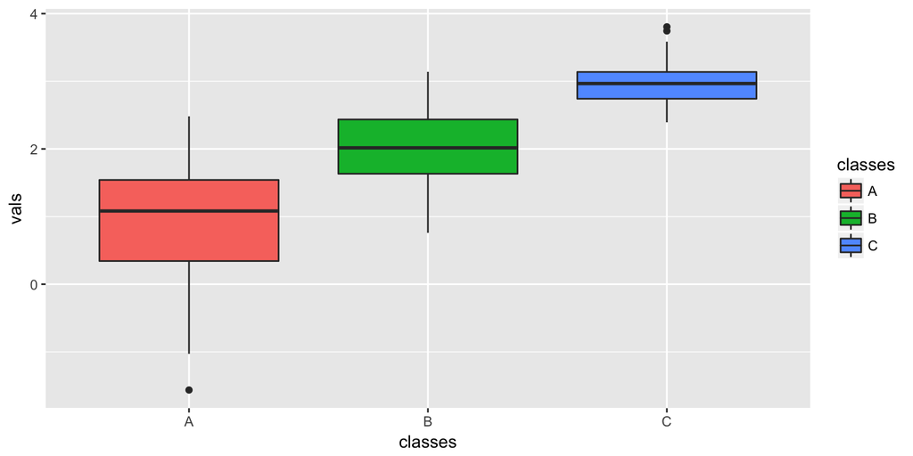

```r
ggplot(df,mapping=aes(x=classes,y=vals,fill=classes)) + geom_boxplot()
```

## Graphics are for addressing questions

- Do cars with big engines use more fuel than cars with small engines?
- You probably already have an answer, but try to make your answer precise.
- What does the relationship between engine size and fuel efficiency look like?
- Is it positive? Negative? Linear? Nonlinear?

## Some data

```r
mpg
```

```
## # A tibble: 234 × 11
##    manufacturer      model displ  year   cyl      trans   drv   cty   hwy
##           <chr>      <chr> <dbl> <int> <int>      <chr> <chr> <int> <int>
## 1          audi         a4   1.8  1999     4   auto(l5)     f    18    29
## 2          audi         a4   1.8  1999     4 manual(m5)     f    21    29
## 3          audi         a4   2.0  2008     4 manual(m6)     f    20    31
## 4          audi         a4   2.0  2008     4   auto(av)     f    21    30
## 5          audi         a4   2.8  1999     6   auto(l5)     f    16    26
## 6          audi         a4   2.8  1999     6 manual(m5)     f    18    26
## 7          audi         a4   3.1  2008     6   auto(av)     f    18    27
## 8          audi a4 quattro   1.8  1999     4 manual(m5)     4    18    26
## 9          audi a4 quattro   1.8  1999     4   auto(l5)     4    16    25
## 10         audi a4 quattro   2.0  2008     4 manual(m6)     4    20    28
## # ... with 224 more rows, and 2 more variables: fl <chr>, class <chr>
```

Among the variables in `mpg` are:

1. `displ`, a car’s engine size, in litres.
2. `hwy`, a car’s fuel efficiency on the highway, in miles per gallon (mpg). A car with a low fuel efficiency consumes more fuel than a car with a high fuel efficiency when they travel the same distance.

## First plot

```r
ggplot(data = mpg) +
  geom_point(mapping = aes(x = displ, y = hwy))
```

[output not shown]

- `ggplot()` creates a coordinate system.
- The first argument of `ggplot()` is the dataset to use in the graph. So `ggplot(data = mpg)` creates an empty graph, but it’s not very interesting.
- `geom_point()` adds a layer of points to your plot.
- Each geom function in ggplot2 takes a `mapping` argument.
- This defines how variables in your dataset are mapped to visual properties.
- The `mapping` argument is always paired with `aes()`, and the `x` and `y` arguments of `aes()` specify which variables to map to the x and y axes.
- ggplot2 looks for the mapped variable in the `data` argument, in this case, `mpg`.

## Again…

Note:

```r
ggplot(mpg) + geom_point(aes(displ,hwy))
```

In general:

```
ggplot(data = <DATA>) +
  <GEOM_FUNCTION>(mapping = aes(<MAPPINGS>))
```

## Aesthetics

> “The greatest value of a picture is when it forces us to notice what we never expected to see.” — John Tukey

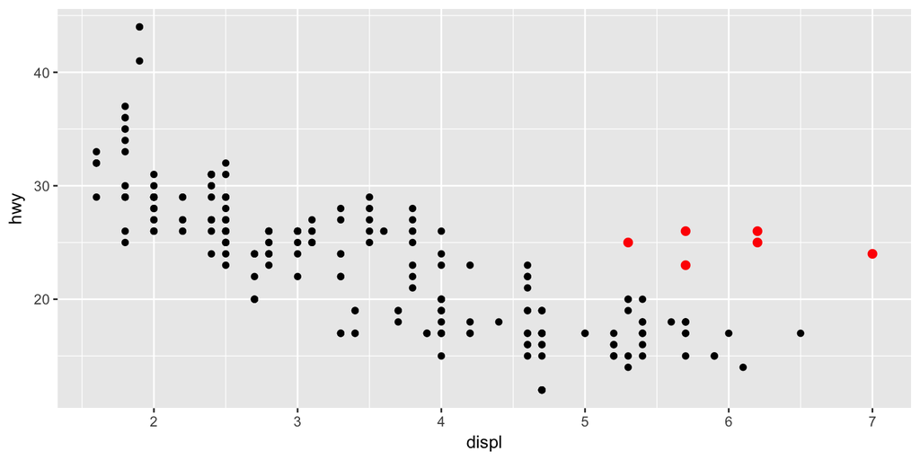

- The red points seem to be outliers.

## Coloring

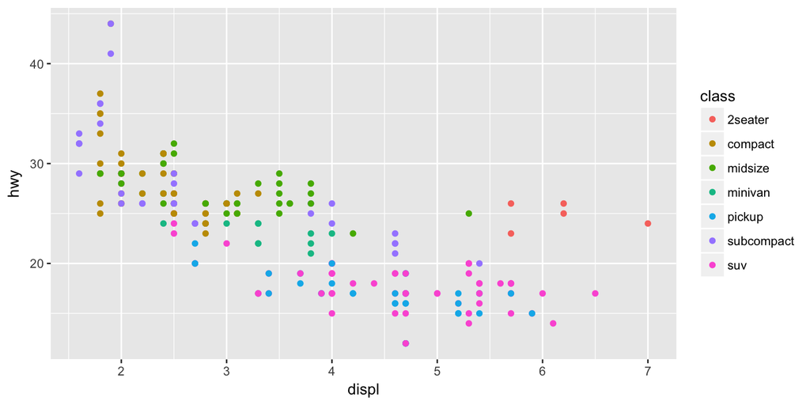

```r
ggplot(data = mpg) +
  geom_point(mapping = aes(x = displ, y = hwy, color = class))
```

## Size

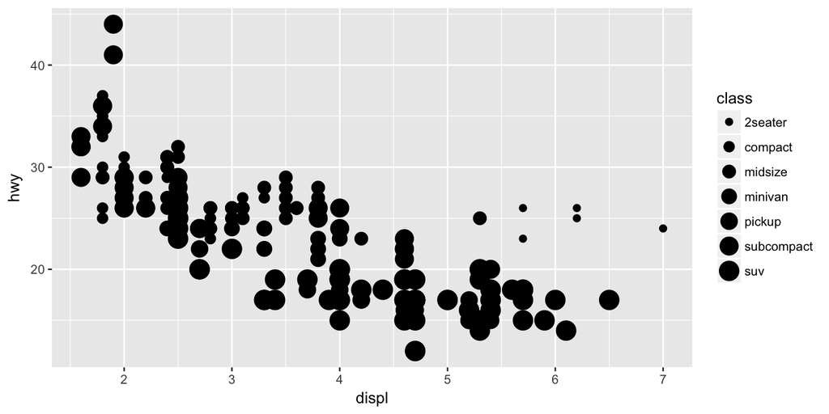

```r
ggplot(data = mpg) +
  geom_point(mapping = aes(x = displ, y = hwy, size = class))
```

## Transparency and shape

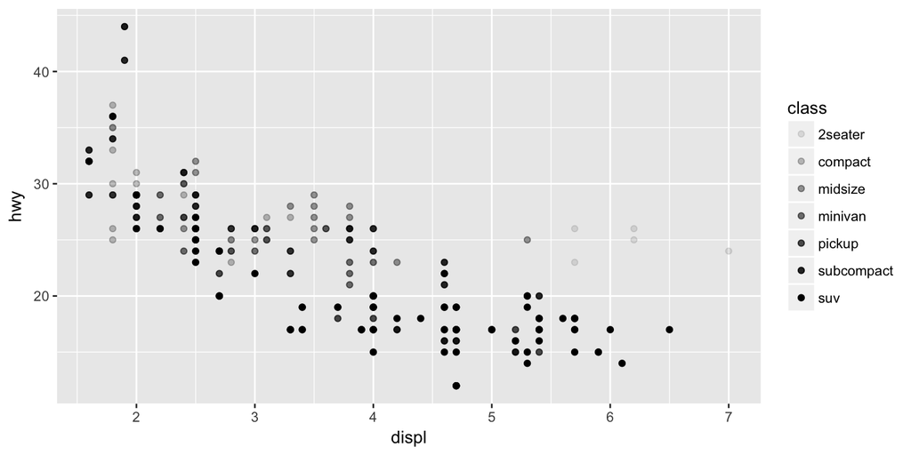

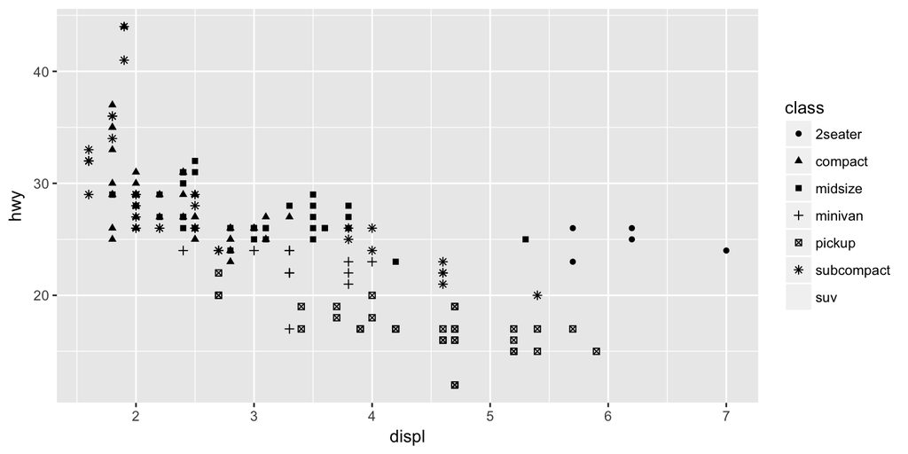

```r
# Left
ggplot(data = mpg) +
  geom_point(mapping = aes(x = displ, y = hwy, alpha = class))

# Right
ggplot(data = mpg) +
  geom_point(mapping = aes(x = displ, y = hwy, shape = class))
```

## Just like some color

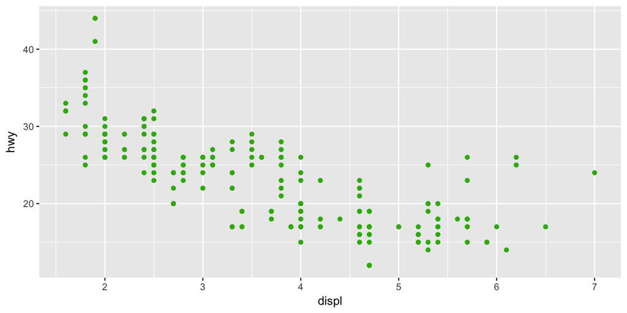

```r
ggplot(data = mpg) +
  geom_point(mapping = aes(x = displ, y = hwy), color = "#31B404")
```

## Facets

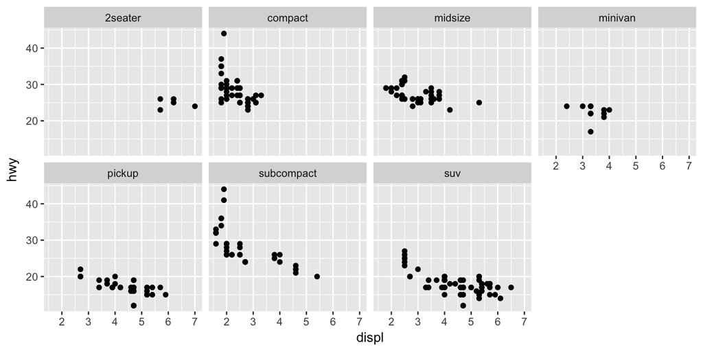

```r
ggplot(data = mpg) +
  geom_point(mapping = aes(x = displ, y = hwy)) +
  facet_wrap(~ class, nrow = 2)
```

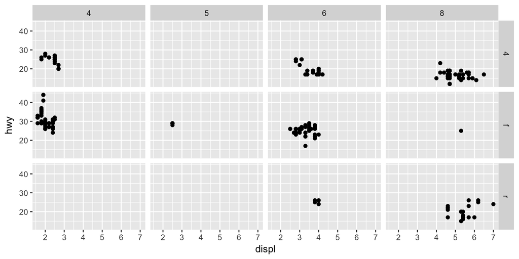

```r
ggplot(data = mpg) +
  geom_point(mapping = aes(x = displ, y = hwy)) +
  facet_grid(drv ~ cyl)
```

## Rows or columns

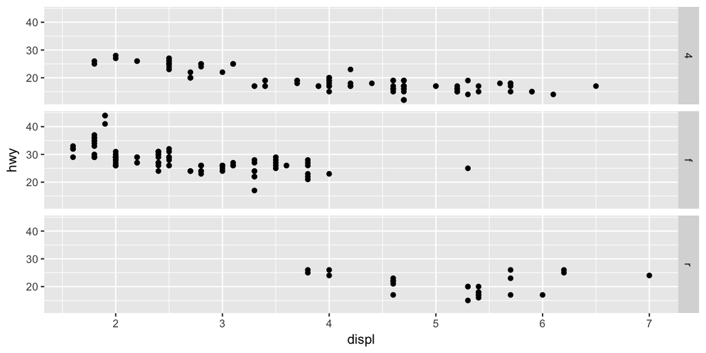

```r
ggplot(data = mpg) +
  geom_point(mapping = aes(x = displ, y = hwy)) +
  facet_grid(drv ~ .)
```

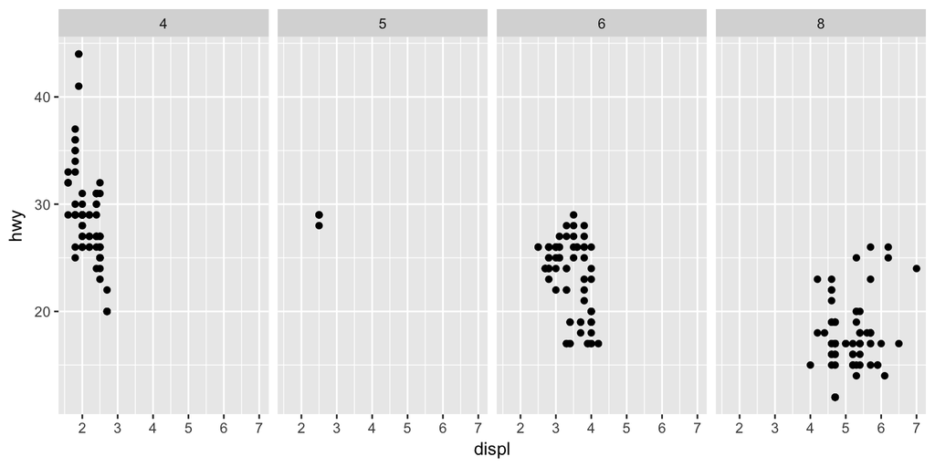

```r
ggplot(data = mpg) +
  geom_point(mapping = aes(x = displ, y = hwy)) +
  facet_grid(. ~ cyl)
```

## What are geoms?

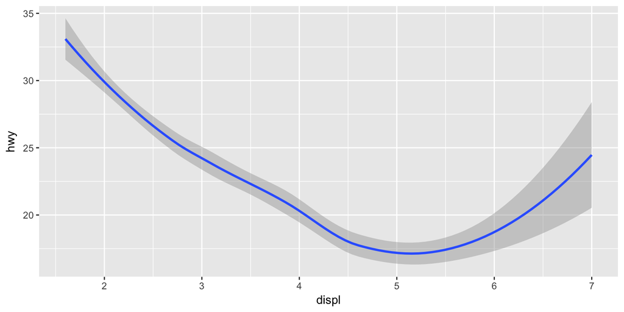

```r
ggplot(data = mpg) +
  geom_point(mapping = aes(x = displ, y = hwy))

ggplot(data = mpg) +
  geom_smooth(mapping = aes(x = displ, y = hwy))
```

- Different **geoms** lead to different kinds of geometric objects.
- bar charts use bar geoms,
- line charts use line geoms,
- boxplots use boxplot geoms
- Scatterplots break the trend; they use the point geom.

## Line types

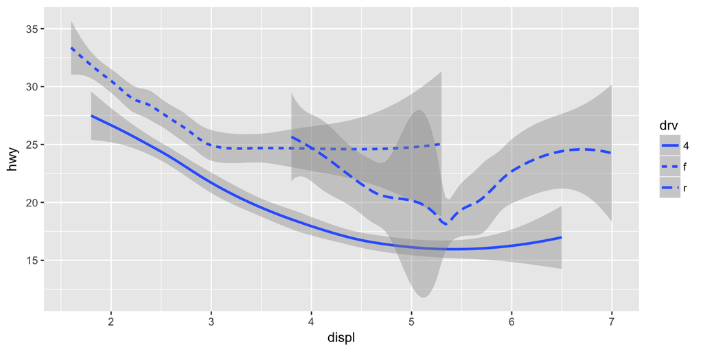

```r
ggplot(data = mpg) +
  geom_smooth(mapping = aes(x = displ, y = hwy, linetype = drv))
```

- One line describes all of the points with a `4` value,
- one line describes all of the points with an `f` value,
- and one line describes all of the points with an `r` value.

## More clear

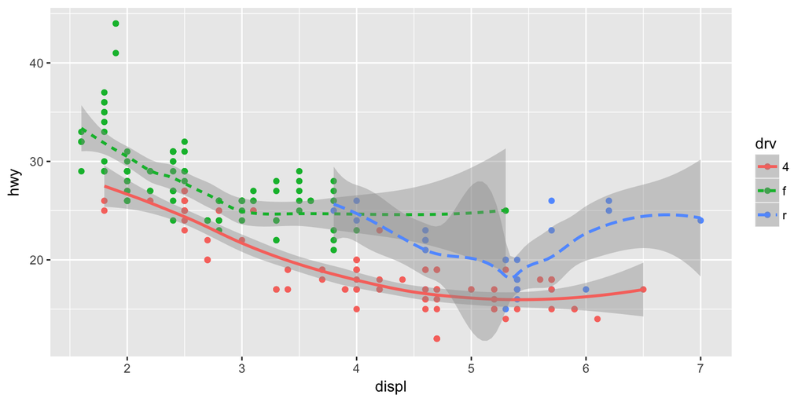

## Grouping

- Many geoms use a single geometric object to display multiple rows of data.
- you can set the `group` aesthetic to a categorical variable to draw multiple objects.
- ggplot2 will draw a separate object for each unique value of the grouping variable.
- the `group` aesthetic by itself does not add a legend or distinguishing features to the geoms (`linetype` or `color` do).

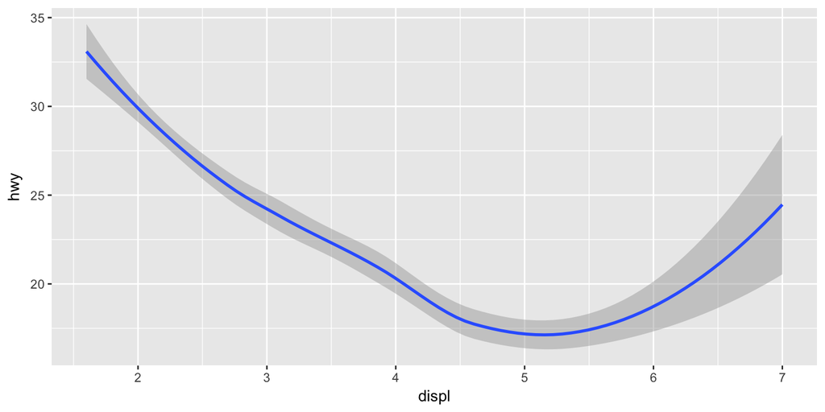

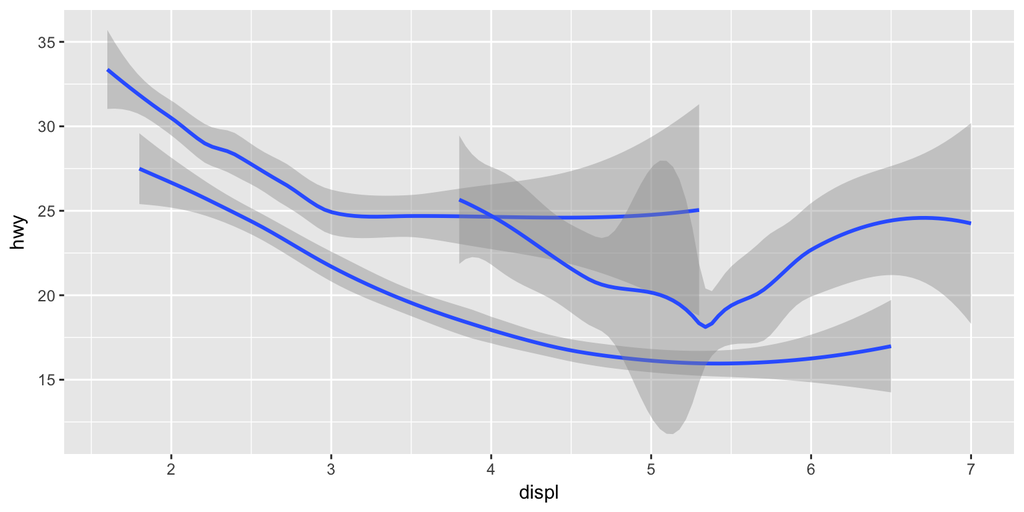

```r
ggplot(data = mpg) +
  geom_smooth(mapping = aes(x = displ, y = hwy))

ggplot(data = mpg) +
  geom_smooth(mapping = aes(x = displ, y = hwy, group = drv))
```

## Multiple geoms

- To display multiple geoms in the same plot, add multiple geom functions to `ggplot()`:

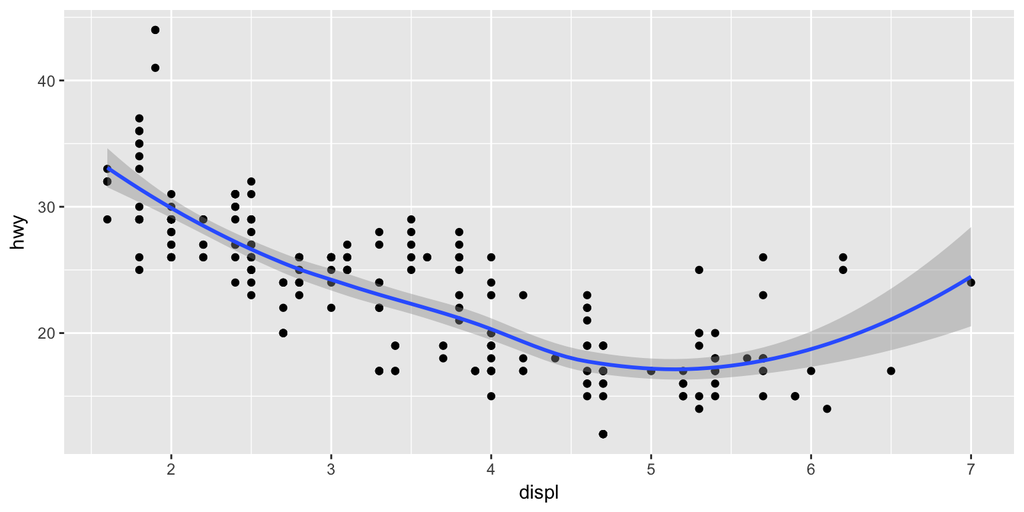

```r
ggplot(data = mpg) +
  geom_point(mapping = aes(x = displ, y = hwy)) +
  geom_smooth(mapping = aes(x = displ, y = hwy))
```

- Creates duplication, annoying to type `aes(x = displ, y = hwy)`.

```r
ggplot(data = mpg, mapping = aes(x = displ, y = hwy)) +
  geom_point() +
  geom_smooth()
```

- mappings in `ggplot` are *global*, in a geom, they are *local* to the geom.

## Ex

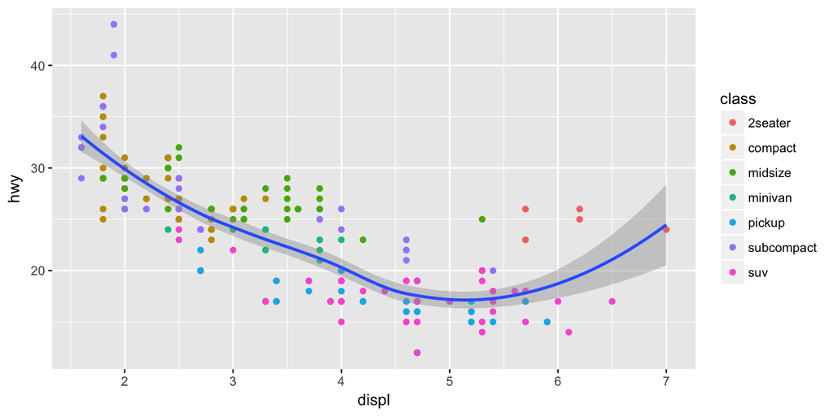

```r
ggplot(data = mpg, mapping = aes(x = displ, y = hwy)) +
  geom_point(mapping = aes(color = class)) +
  geom_smooth()
```

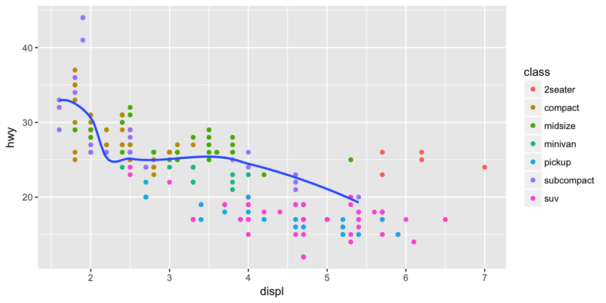

```r
ggplot(data = mpg, mapping = aes(x = displ, y = hwy)) +
  geom_point(mapping = aes(color = class)) +
  geom_smooth(data = filter(mpg, class == "subcompact"), se = FALSE)
```